# Homework 10

Suggested Solutions

# Part I

1. c
2. a
3. c
4. d
5. a
6. b

# Part II

## Problem 1

### 1.1

CPI: 100, 86.36, 61.36

### 1.2

GDP: 22000, 16500, 12000

### 1.3

RGDP: 22000, 18000, 14000[^1]

### 1.4

RGDP: 13500[^2], 12750, 12000

### 1.5

GDP Deflator: 100, 91.67, 85.71

## Problem 2

### 2.1

$\left(\frac{15676}{10642}\right)^{\frac{1}{10}}-1=.039=3.9\%$

### 2.2

Real GDP in 2002: $10642\times100/92.2=11542.3$

Real GDP in 2012: $15676\times100/115.4=13584.06$

Annual growth rate: $\left(\frac{13584.06}{11542.3}\right)^{\frac{1}{10}}-1=.016=1.6\%$

# Part III

## Problem 1

### 1.1

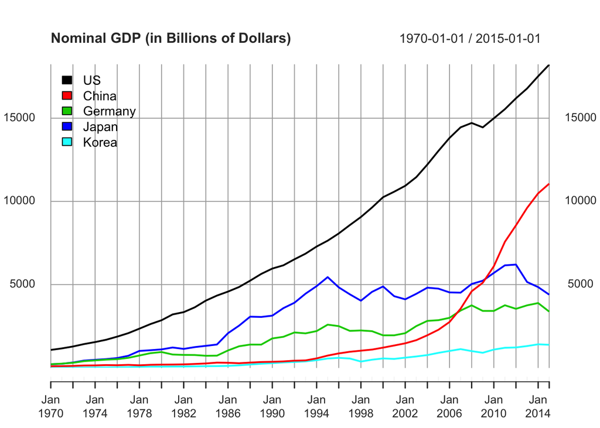

```r
library(quantmod)
billion = 1e9
t = "1970-01-01/2015-01-01"

us = getSymbols('GDPA',src='FRED',auto.assign=FALSE)
china = getSymbols('MKTGDPCNA646NWDB',src='FRED',auto.assign=FALSE)
germany = getSymbols('MKTGDPDEA646NWDB',src='FRED',auto.assign=FALSE)
japan = getSymbols('MKTGDPJPA646NWDB',src='FRED',auto.assign=FALSE)
korea = getSymbols('MKTGDPKRA646NWDB',src='FRED',auto.assign=FALSE)

us = us[t]
china = china[t]/billion
germany = germany[t]/billion
japan = japan[t]/billion
korea = korea[t]/billion

GDP = cbind(us,china,germany,japan,korea)
colnames(GDP) <- c("US","China","Germany","Japan","Korea")

plot(GDP,legend.loc='topleft',auto.legend=TRUE,main="Nominal GDP (in Billions of Dollars)")
```

### 1.2

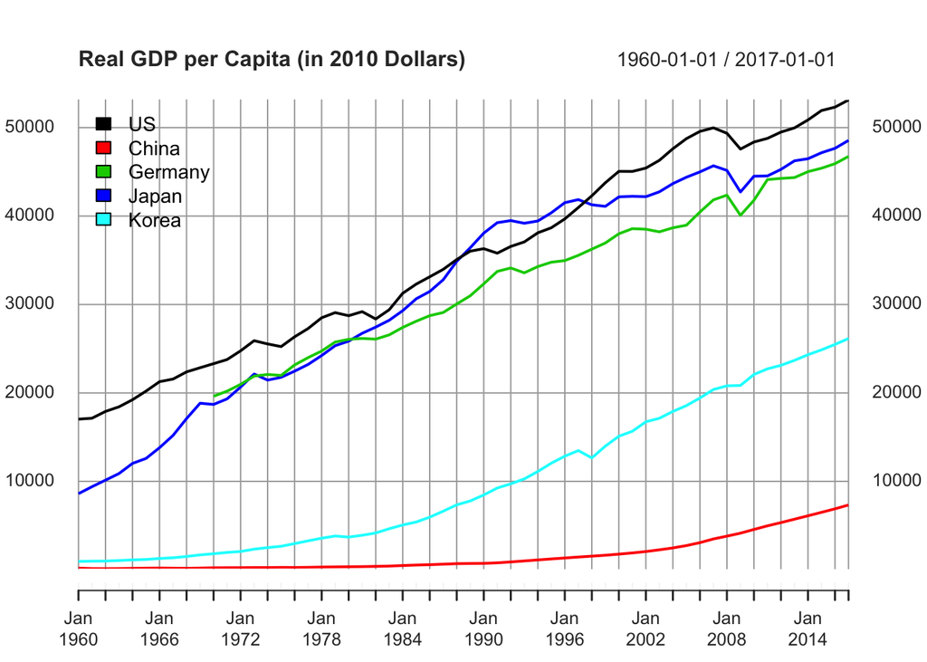

```r
t = "1970-01-01/2015-01-01"
us = getSymbols('NYGDPPCAPKDUSA',src='FRED',auto.assign=FALSE)
china = getSymbols('NYGDPPCAPKDCHN',src='FRED',auto.assign=FALSE)
germany = getSymbols('NYGDPPCAPKDDEU',src='FRED',auto.assign=FALSE)
japan = getSymbols('NYGDPPCAPKDJPN',src='FRED',auto.assign=FALSE)
korea = getSymbols('NYGDPPCAPKDKOR',src='FRED',auto.assign=FALSE)

GDPcapita = cbind(us,china,germany,japan,korea)
GDPcaptita = GDPcapita[t]
colnames(GDPcapita) <- c("US","China","Germany","Japan","Korea")

plot(GDPcapita,legend.loc='topleft',auto.legend=TRUE,main="Real GDP per Capita (in 2010 Dollars)")
```

### 1.3

Largest growth: China; Second largest growth: Korea

[figure not shown]

```r
us = us/coredata(us)[1]
china = china/coredata(china)[1]
germany = germany/coredata(germany)[1]
japan = japan/coredata(japan)[1]
korea = korea/coredata(korea)[1]

GDPcapitaIndex = cbind(us,china,germany,japan,korea)
colnames(GDPcapitaIndex) <- c("US","China","Germany","Japan","Korea")

plot(GDPcapitaIndex,legend.loc='topleft',auto.legend=TRUE,main="Real GDP per Capita Index (1970=1)")
```

## Problem 2

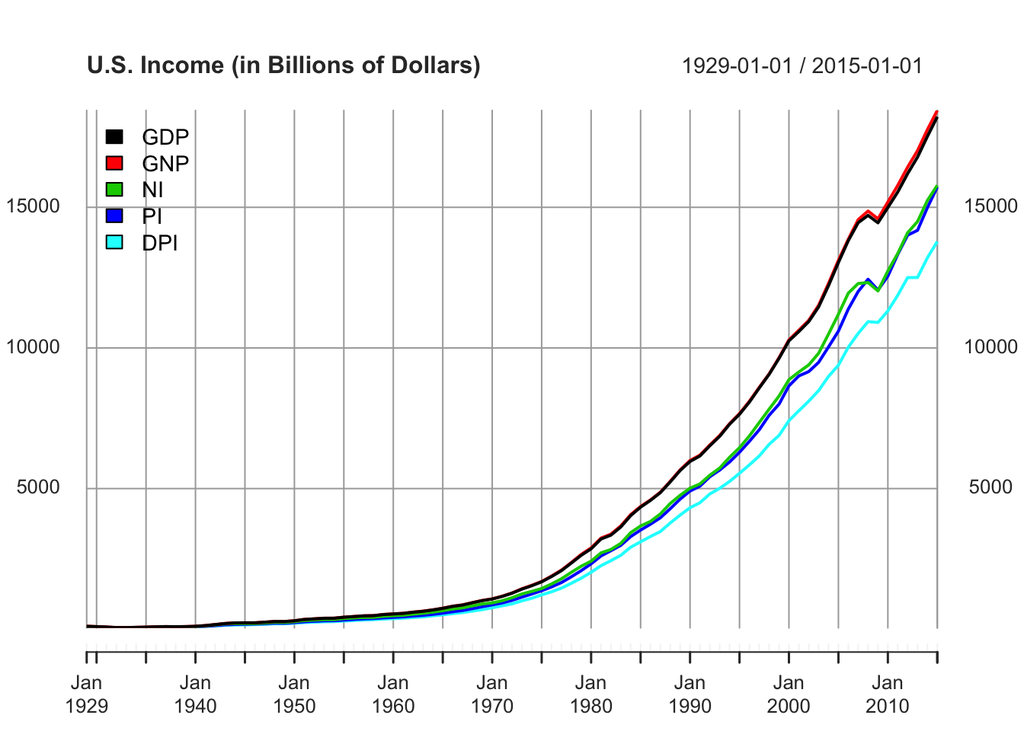

```r
t = "1929-01-01/2015-01-01"

gdp = getSymbols('GDPA',src='FRED',auto.assign=FALSE)
gnp = getSymbols('GNPA',src='FRED',auto.assign=FALSE)
ni = getSymbols('A032RC1A027NBEA',src='FRED',auto.assign=FALSE)
pi = getSymbols('A065RC1A027NBEA',src='FRED',auto.assign=FALSE)
dpi = getSymbols('A067RC1A027NBEA',src='FRED',auto.assign=FALSE)

data = cbind(gdp,gnp,ni,pi,dpi)
colnames(data) <- c("GDP","GNP","NI","PI","DPI")

plot(data[t],legend.loc='topleft',auto.legend=TRUE,main="U.S. Income (in Billions of Dollars)")
```

## Problem 3

### 3.1

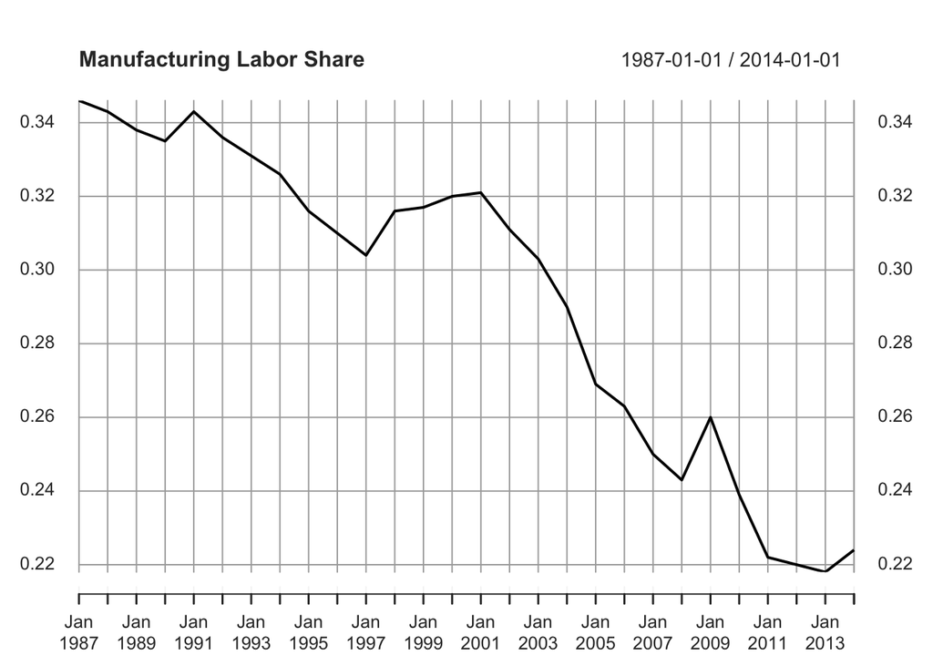

```r
t = "1987-01-01/2014-01-01"

ls = getSymbols('MPU9900681',src='FRED',auto.assign=FALSE)
durable = getSymbols('MPU9920681',src='FRED',auto.assign=FALSE)
nondurable = getSymbols('MPU9910681',src='FRED',auto.assign=FALSE)

plot(ls[t],main="Manufacturing Labor Share")
```

### 3.2

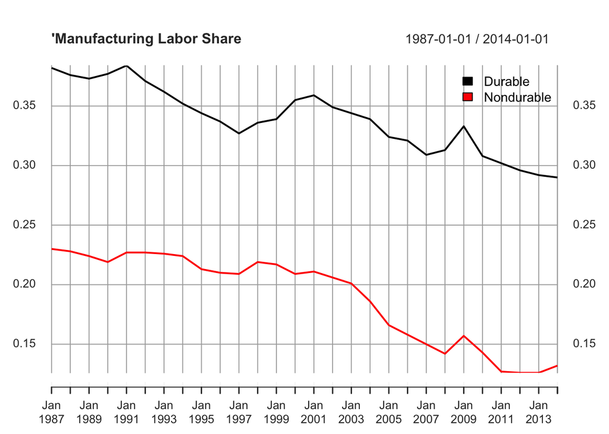

```r
data = cbind(durable,nondurable)
colnames(data) <- c("Durable","Nondurable")

plot(data[t],legend.loc='topright',auto.legend=TRUE,main="'Manufacturing Labor Share")
```

### 3.4

Technology growth, globalization (trade + outsourcing)

## Problem 4

### 4.1

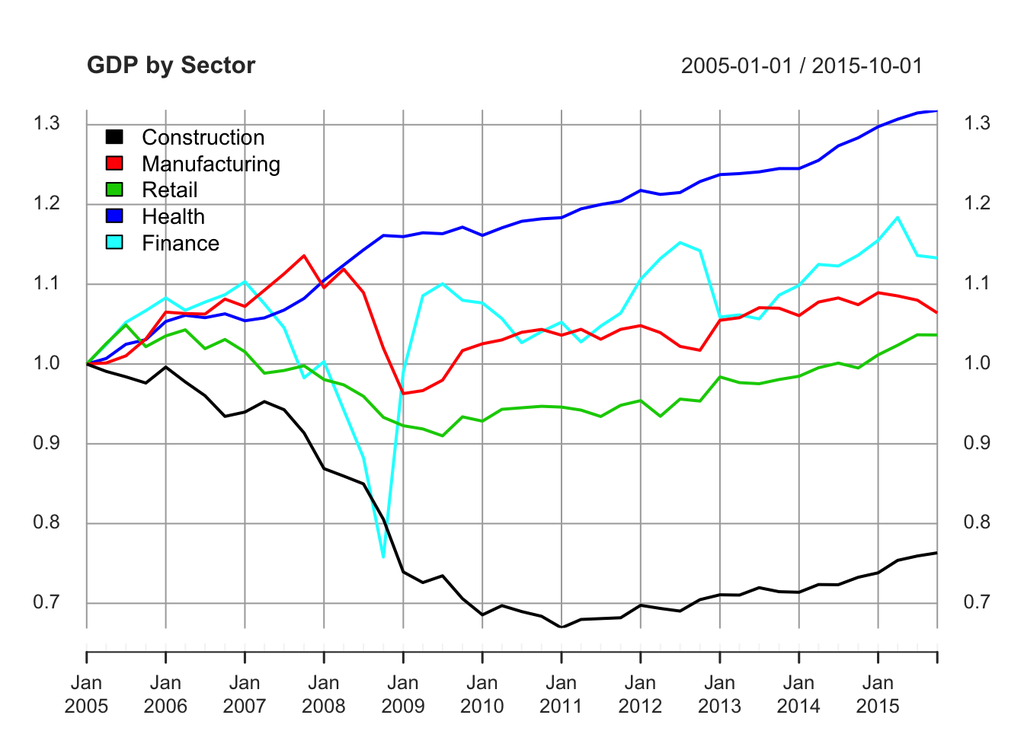

```r
t = "2005-01-01/2015-12-31"

con = getSymbols('USCONSTRQGSP',src='FRED',auto.assign=FALSE)
man = getSymbols('USMANRQGSP',src='FRED',auto.assign=FALSE)
retail = getSymbols('USRETAILRQGSP',src='FRED',auto.assign=FALSE)
health = getSymbols('USHLTHSOCASSRQGSP',src='FRED',auto.assign=FALSE)
fin = getSymbols('USFININSRQGSP',src='FRED',auto.assign=FALSE)

con = con[t]
man = man[t]
retail = retail[t]
health = health[t]
fin = fin[t]

con = con/coredata(con)[1]
man = man/coredata(man)[1]
retail = retail/coredata(retail)[1]
health = health/coredata(health)[1]
fin = fin/coredata(fin)[1]

data = cbind(con,man,retail,health,fin)
colnames(data) <- c("Construction","Manufacturing","Retail","Health","Finance")
plot(data,legend.loc='topleft',auto.legend=TRUE,main="GDP by Sector")
```

### 4.2

Construction started to decline first. The Financial sector experienced the most precipitous decline during the crisis but also recovered the fastest. Healthcare grew during the crisis. The Construction sector still hasn’t grown back to its 2005 level.

## Problem 5

### 5.1

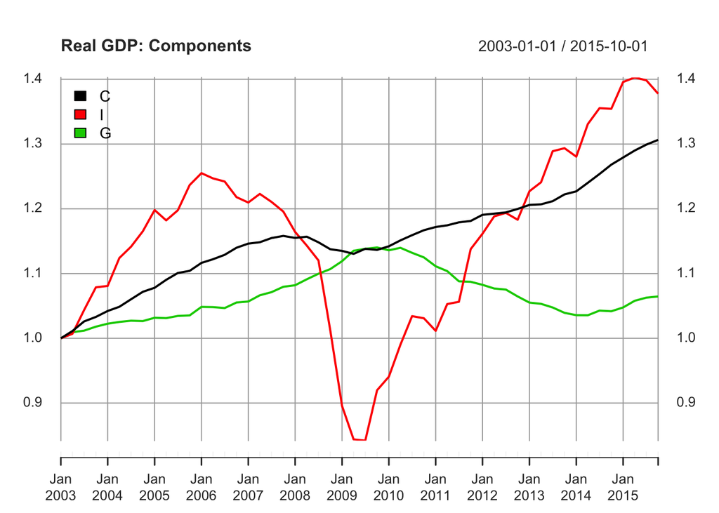

```r
t = "2003-01-01/2015-12-31"

rc = getSymbols('PCECC96',src='FRED',auto.assign=FALSE)
ri = getSymbols('GPDIC1',src='FRED',auto.assign=FALSE)
rg = getSymbols('GCEC1',src='FRED',auto.assign=FALSE)

rc = rc[t]
ri = ri[t]
rg = rg[t]

rc = rc/coredata(rc)[1]
ri = ri/coredata(ri)[1]
rg = rg/coredata(rg)[1]

data = cbind(rc,ri,rg)
colnames(data) <- c("C","I","G")
plot(data,legend.loc='topleft',auto.legend=TRUE,main="Real GDP: Components")
```

### 5.2

Investment started to decline in 2006.Q1 and experienced the most significant drop during the financial crisis. Consumption started to drop in 2008.Q2 and began to recover in 2009.Q2. Government spending increased during and immediately after the financial crisis.

## Problem 6

### 6.1

[figure not shown]

```r
t = "2003-01-01/2015-12-31"

durable = getSymbols('PCDGCC96',src='FRED',auto.assign=FALSE)
nondurable = getSymbols('PCNDGC96',src='FRED',auto.assign=FALSE)
service = getSymbols('PCESVC96',src='FRED',auto.assign=FALSE)

durable = durable[t]
nondurable = nondurable[t]
service = service[t]

durable = durable/coredata(durable)[1]
nondurable = nondurable/coredata(nondurable)[1]
service = service/coredata(service)[1]

data = cbind(durable,nondurable,service)
colnames(data) <- c('Durable Goods','Nondurable Goods','Service')
plot(data,legend.loc='topleft',auto.legend=TRUE,main="Personal Consumption Expenditure (in Billions of Chained 2009 Dollars)")
```

### 6.2

Consumption on durable goods dropped the most during the recession but also recovered and has seen the strongest growth post-recession. Service consumption was least affected by the recession.

## Problem 7

### 7.1

[figure not shown]

```r
t = "2003-01-01/2015-12-31"

ri = getSymbols('PRFIC96',src='FRED',auto.assign=FALSE)
bi = getSymbols('PNFIC96',src='FRED',auto.assign=FALSE)

ri = ri[t]
bi = bi[t]

ri = ri/coredata(ri)[1]
bi = bi/coredata(bi)[1]

data = cbind(ri,bi)
colnames(data) <- c('Residential Investment','Business Fixed Investment')
plot(data,legend.loc='topleft',auto.legend=TRUE,main="Investment (in Billions of Chained 2009 Dollars)")
```

### 7.2

Residential investment started to decline in mid-2005 and started to grow in mid-2010. Business fixed investment started to decline at the beginning of 2008 and started to recover toward the end of 2009. Today, residential investment still hasn’t recovered to its 2007 level.

## Problem 1

### 1.1

2009

### 1.2

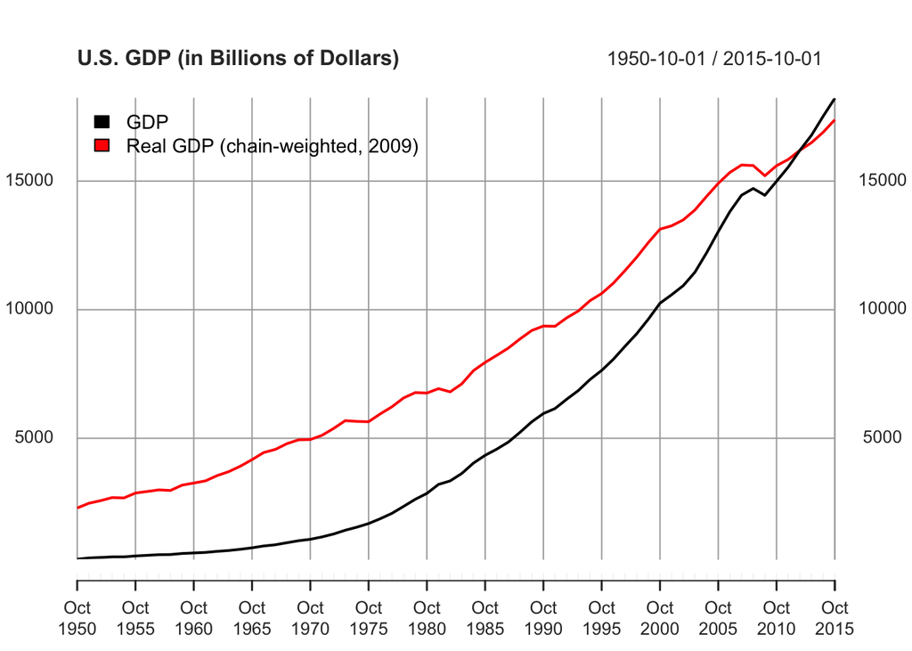

```r
t = "1950-01-01/2015-10-01"

gdpQ = getSymbols('GDP',src='FRED',auto.assign=FALSE)
rgdpQ = getSymbols('GDPC1',src='FRED',auto.assign=FALSE)

gdpQ = gdpQ[t]
rgdpQ = rgdpQ[t]

# convert quarterly data into annual data
gdp = apply.yearly(gdpQ,mean)
rgdp = apply.yearly(rgdpQ,mean)

data = cbind(gdp,rgdp)
colnames(data) <- c("GDP","Real GDP (chain-weighted, 2009)")

plot(data,legend.loc='topleft',auto.legend=TRUE,main="U.S. GDP (in Billions of Dollars)")
```

### 1.3

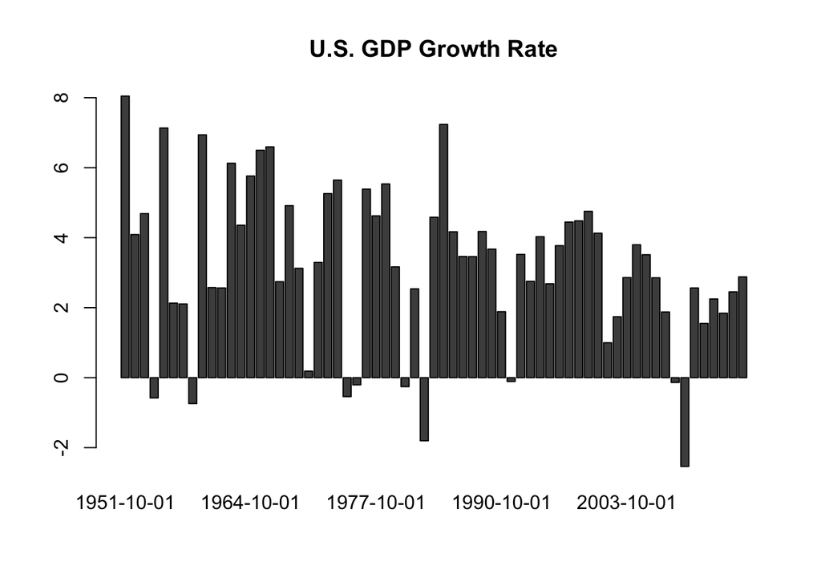

```r
grgdp = (rgdp/lag(rgdp)-1)*100
grgdp = grgdp[-1,] #get rid of the first row, which is NA
barplot(grgdp,main="U.S. GDP Growth Rate")
```

## Problem 2

### 2.1

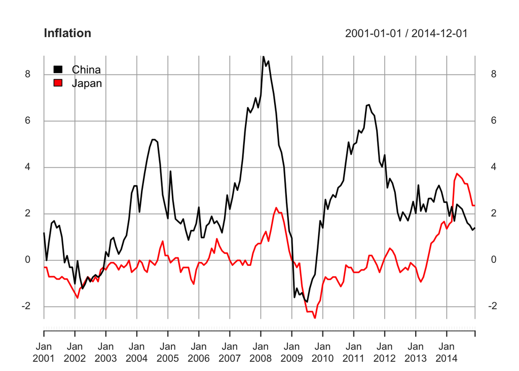

```r
t = "2000-01-01/2014-12-01"

china = getSymbols('CHNCPIALLMINMEI',src='FRED',auto.assign=FALSE)
japan = getSymbols('JPNCPIALLMINMEI',src='FRED',auto.assign=FALSE)

china = china[t]
japan = japan[t]

# calculate yoy inflation rate
pi.china = (china/lag(china,12)-1)*100
pi.japan = (japan/lag(japan,12)-1)*100

pi.china = pi.china[-c(1:12),] #get rid of the first 12 rows, which are NA
pi.japan = pi.japan[-c(1:12),] #get rid of the first 12 rows, which are NA

data = cbind(pi.china,pi.japan)
colnames(data) <- c("China","Japan")

plot(data,legend.loc='topleft',auto.legend=TRUE,main="Inflation")
```

### 2.2

```r
sum(pi.japan < 0)
```

```
## [1] 102
```

## Problem 3

### 3.1

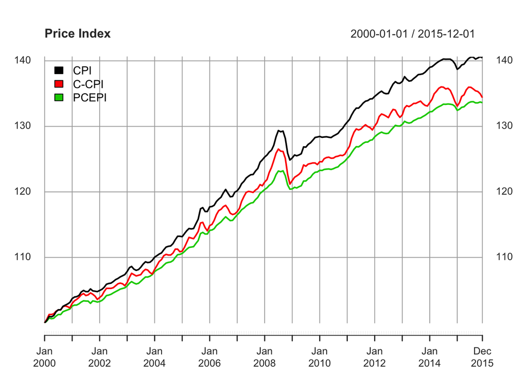

```r
t = "2000-01-01/2015-12-01"

cpi = getSymbols('CPIAUCSL',src='FRED',auto.assign=FALSE)
ccpi = getSymbols('SUUR0000SA0',src='FRED',auto.assign=FALSE)
pcepi = getSymbols('PCEPI',src='FRED',auto.assign=FALSE)

cpi = cpi[t]
ccpi = ccpi[t]
pcepi = pcepi[t]

# set 2000.01 to be base period
cpi = cpi/coredata(cpi)[1]*100
ccpi = ccpi/coredata(ccpi)[1]*100
pcepi = pcepi/coredata(pcepi)[1]*100

data = cbind(cpi,ccpi,pcepi)
colnames(data) <- c("CPI","C-CPI","PCEPI")

plot(data,legend.loc='topleft',auto.legend=TRUE,main="Price Index")
```

### 3.2

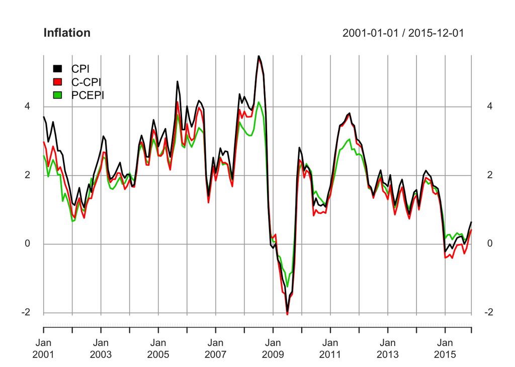

```r
pi.cpi = (cpi/lag(cpi,12)-1)*100
pi.ccpi = (ccpi/lag(ccpi,12)-1)*100
pi.pcepi = (pcepi/lag(pcepi,12)-1)*100

data = cbind(pi.cpi,pi.ccpi,pi.pcepi)
colnames(data) <- c("CPI","C-CPI","PCEPI")
data = data[-c(1:12),] #get rid of the first 12 rows, which are NA

plot(data,legend.loc='topleft',auto.legend=TRUE,main="Inflation")
```

### 3.3

On average CPI-U > C-CPI-U > PCEPI

### 3.4

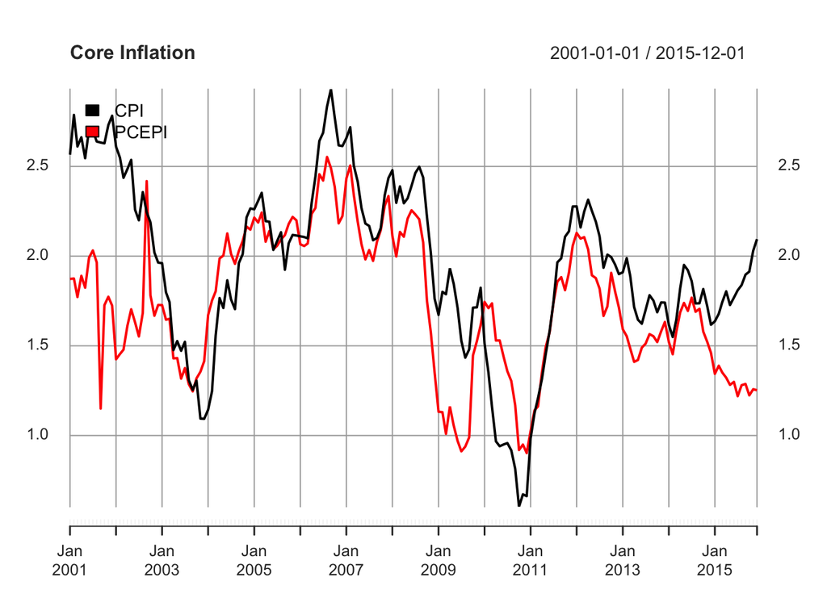

```r
t = "2000-01-01/2015-12-01"

cpicore = getSymbols('CPILFESL',src='FRED',auto.assign=FALSE)
pcepicore = getSymbols('PCEPILFE',src='FRED',auto.assign=FALSE)

cpicore = cpicore[t]
pcepicore = pcepicore[t]

pi.cpicore = (cpicore/lag(cpicore,12)-1)*100
pi.pcepicore = (pcepicore/lag(pcepicore,12)-1)*100

data = cbind(pi.cpicore,pi.pcepicore)
colnames(data) <- c("CPI","PCEPI")
data = data[-c(1:12),] #get rid of the first 12 rows, which are NA

plot(data,legend.loc='topleft',auto.legend=TRUE,main="Core Inflation")
```

### 3.4

1. higher; higher
2. lower than; higher than

### 3.6

Overall food and energy prices were falling in 2015, contributing negatively to both CPI-U and PCEPI. Altogether food and energy have a larger weight in the CPI basket than in the PCEPI, causing CPI to drop more than PCEPI in 2015. Hence even though core CPI inflation was higher than core PCEPI inflation, headline CPI inflation was lower than headline PCEPI inflation.

### 3.7

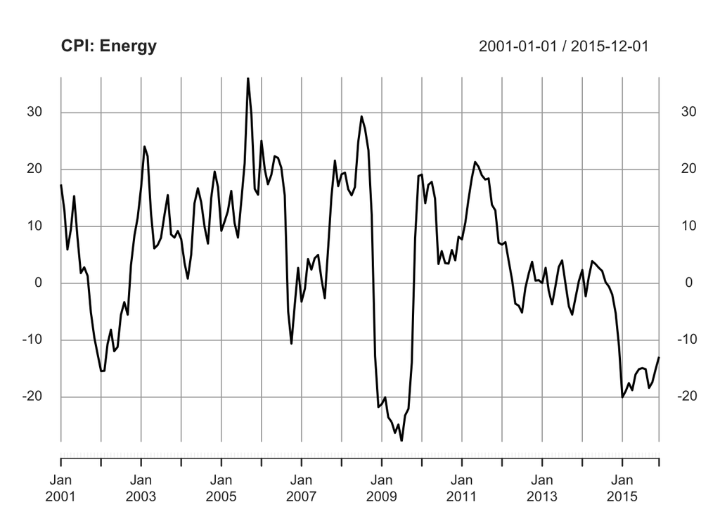

```r
energy = getSymbols('CPIENGSL',src='FRED',auto.assign=FALSE)
pi.energy = (energy/lag(energy,12)-1)*100
t = "2001-01-01/2015-12-01" # time range for inflation rate is 2001.01 - 2015.12
plot(pi.energy[t],main="CPI: Energy")
```

### 3.8

Decreasing. Average inflation rate:

```r
mean(pi.energy["2015"])
```

```
## [1] -16.66433
```

## Problem 4

### 4.1

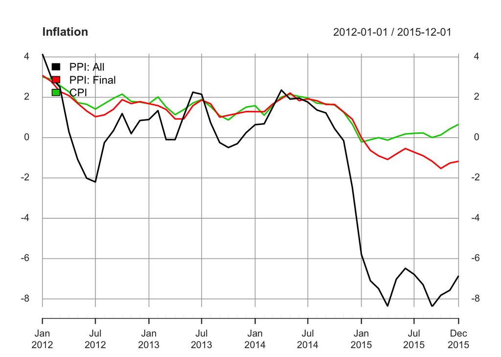

```r
ppi = getSymbols('PPIACO',src='FRED',auto.assign=FALSE)
ppif = getSymbols('PPIFIS',src='FRED',auto.assign=FALSE)
cpi = getSymbols('CPIAUCSL',src='FRED',auto.assign=FALSE)

# calculate yoy inflation rate
pi.ppi = (ppi/lag(ppi,12)-1)*100
pi.ppif = (ppif/lag(ppif,12)-1)*100
pi.cpi = (cpi/lag(cpi,12)-1)*100

data = cbind(pi.ppi,pi.ppif,pi.cpi)
colnames(data) <- c("PPI: All","PPI: Final","CPI")

t = "2012-01-01/2015-12-01" # plot inflation from 2012-01 to 2015-12

plot(data[t],legend.loc='topleft',auto.legend=TRUE,main="Inflation")
```

### 4.2

PPI: All is more volatile. PPI: Final tracks CPI better.

### 4.3

Rising housing cost (shelter price) in 2015 contributes to CPI but not PPI.

### 4.4

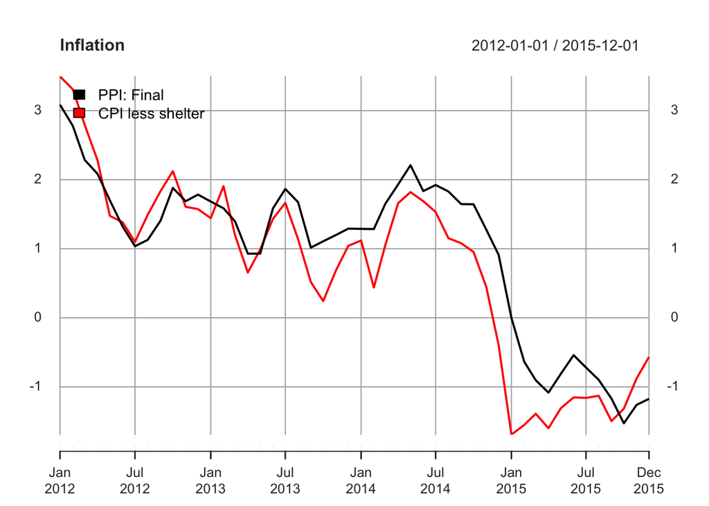

```r
cpiLessShelter = getSymbols('CUSR0000SA0L2',src='FRED',auto.assign=FALSE)
pi.cpiLessShelter = (cpiLessShelter/lag(cpiLessShelter,12)-1)*100

data = cbind(pi.ppif,pi.cpiLessShelter)
colnames(data) <- c("PPI: Final","CPI less shelter")

t = "2012-01-01/2015-12-01" # plot inflation from 2012-01 to 2015-12

plot(data[t],legend.loc='topleft',auto.legend=TRUE,main="Inflation")
```

### 4.5

faster; Reason: Housing has a larger weight in the CPI basket than in the PCEPI.

[^1]: $14000 = 20\times200 + 1000\times10$
[^2]: $13500=35\times100+ 500\times20$